# Molecular subtypes, TCR, and neoantigens

Ludmila Danilova & Joe Tandurella

2025-05-01

# Load data

Load patient information from the Nature Cancer paper repo (https://github.com/FertigLab/J15221_trial_paper).

# Molecular subtypes

PAM50 predictions were done using the pam50 R package. https://github.com/hoadley-lab/pam50 Parker et al. 2009, https://pubmed.ncbi.nlm.nih.gov/19204204/

The results of predictions are in the `input_data/PAM50` folder

## TNBCtype assingments

To classify samples according to TNBCtype subtypes, we uploaded the gene expression data to the TNBCtype webtool (https://cbc.app.vumc.org/tnbc/). Out of 37 samples, the tool was able to classify 13 samples from six TNBC patients and one week 8 sample from HR+ patient R-9.

The results of predictions are in the `input_data/TNBCtype` folder

|  | subtype | correlation | p.value |
| --- | --- | --- | --- |
| R-5_Baseline | BL1 | 0.607357696296748 | 0 |
| R-5_C1D1 | BL1 | 0.680956183819704 | 0 |
| R-14_Baseline | IM | 0.692003465119972 | 0 |
| R-14_C1D1 | IM | 0.646977453370319 | 0 |
| R-6_Baseline | BL1 | 0.555958017519891 | 0 |
| R-6_C1D1 | BL1 | 0.556658868014031 | 0 |
| R-6_Week_8 | BL1 | 0.485198303535991 | 0 |
| R-8_Baseline | UNS |  |  |
| R-8_C1D1 | BL2 | 0.301485059131534 | 0 |
| R-16_C1D1 | MSL | 0.157645235837561 | 0 |

[output cut: 3 more lines]

|  | IM | BL1 | MSL | M | BL2 | LAR |
| --- | --- | --- | --- | --- | --- | --- |
| R-5_Baseline | -0.371 | 0.607 | -0.369 | 0.486 | -0.26 | -0.426 |
| R-5_C1D1 | 0.116 | 0.681 | -0.546 | -0.021 | -0.3 | -0.358 |
| R-14_Baseline | 0.692 | 0.054 | -0.017 | -0.648 | -0.234 | 0.1 |
| R-14_C1D1 | 0.647 | -0.099 | 0.147 | -0.622 | -0.05 | 0.115 |
| R-6_Baseline | -0.445 | 0.556 | -0.261 | 0.503 | -0.205 | -0.301 |
| R-6_C1D1 | -0.43 | 0.557 | -0.276 | 0.474 | -0.188 | -0.301 |
| R-6_Week_8 | -0.088 | 0.485 | -0.247 | 0.227 | -0.108 | -0.265 |
| R-8_Baseline | 0.178 | -0.033 | -0.157 | -0.246 | 0.165 | -0.113 |
| R-8_C1D1 | -0.054 | -0.027 | -0.221 | -0.069 | 0.301 | -0.109 |
| R-16_C1D1 | 0.027 | -0.169 | 0.158 | 0.133 | -0.244 | -0.18 |

[output cut: 3 more lines]

## Heatmap

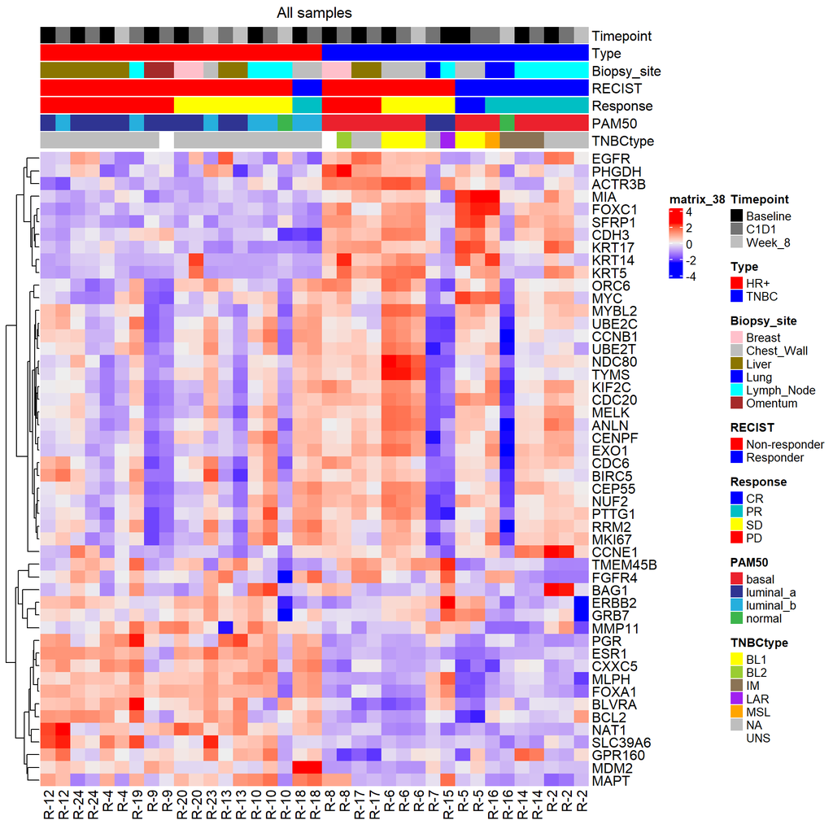

## PAM50 correlation with response

Assign per patient PAM50 subtype to correlate with response. If a patient doesn’t have a baseline samples, use subsequent time points.

|  | patientID | RECIST | Best_Resp | biopsy_site | Timepoint | assignment | TNBCtype |
| --- | --- | --- | --- | --- | --- | --- | --- |
| R-10_Baseline | R-10 | Non-responder | SD | Lymph_Node | Baseline | luminal_b | NA |
| R-12_Baseline | R-12 | Non-responder | PD | Liver | Baseline | luminal_a | NA |
| R-13_C1D1 | R-13 | Non-responder | SD | Liver | C1D1 | luminal_a | NA |
| R-14_Baseline | R-14 | Responder | PR | Lymph_Node | Baseline | basal | IM |
| R-15_Baseline | R-15 | Non-responder | SD | Lymph_Node | Baseline | luminal_a | LAR |
| R-16_C1D1 | R-16 | Responder | PR | Lung | C1D1 | basal | MSL |
| R-17_Baseline | R-17 | Non-responder | PD | Liver | Baseline | basal | NA |
| R-18_Baseline | R-18 | Responder | PR | Chest_Wall | Baseline | luminal_b | NA |
| R-19_C1D1 | R-19 | Non-responder | PD | Lymph_Node | C1D1 | luminal_b | NA |
| R-2_Baseline | R-2 | Responder | PR | Lymph_Node | Baseline | basal | NA |

[output cut: 9 more lines]

```
##
##             Non-responder Responder
##   basal                 3         4
##   luminal_a             8         0
##   luminal_b             3         1
```

```
##
##  Pearson's Chi-squared test
##
## data:  tab
## X-squared = 6.2913, df = 2, p-value = 0.04304
```

```
##
##             HR+ TNBC
##   basal       0    7
##   luminal_a   6    2
##   luminal_b   4    0
```

```
##
##  Pearson's Chi-squared test
##
## data:  tab
## X-squared = 12.983, df = 2, p-value = 0.001516
```

# TCR diversity

T cell receptor repertoires derived from RNA sequencing data were estimated using MiXCR and provided by Personalis Inc. (Menlo Park, CA, USA). We loaded the provided data into R programming environment using the immunarch package and calculated the diversity using the repDiversity function with the chaos1 method. The diversity was visualized as boxplots with pairwise two-sided Wilcoxon rank-sum test p-values.

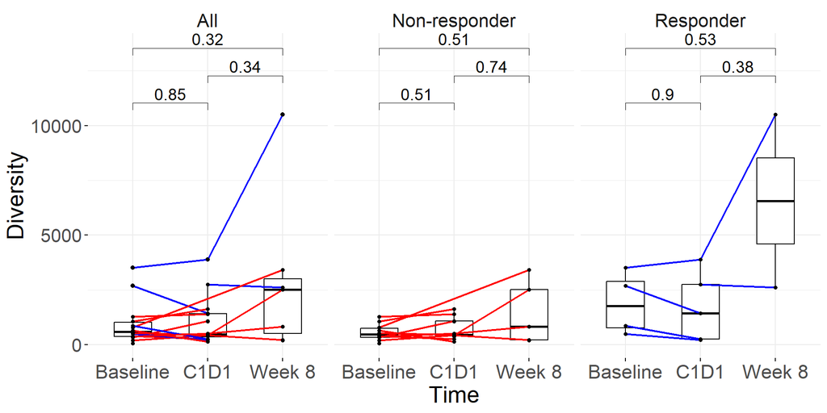

# Strong binding neoantigens

Neoantigen binding affinity was estimated using NetMHCIIPan 4.0 by Personalis Inc. (Menlo Park, CA, USA). To calculate the number of strong binders per sample, we took only peptides of expressed genes, and then for every peptide, we took the minimal predicted HLA rank. After that, we calculated the number of peptides that have rank less than 2 as recommended by Reynisson et al (https://academic.oup.com/nar/article/48/W1/W449/5837056) to be a strong binder.

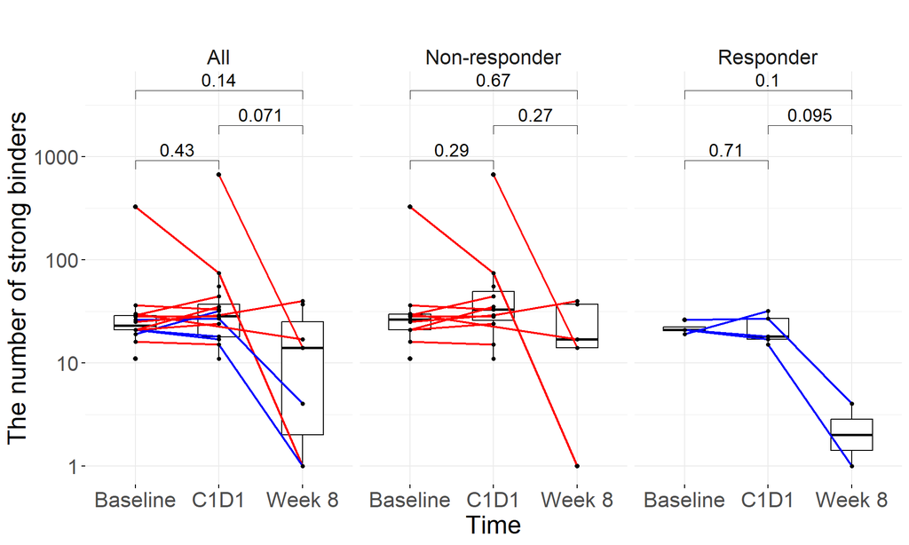